# Live Session 2: Reproducibility and Robustness

Dr Zak Varty

## Welcome!

### This Session:

1. Review of Reproducibility and Robustness (15 mins)
2. Group Discussion (20 mins)
3. Group Feedback (20 mins)

# Review of Reproducibility and Robustness

## Reproducibility and Robustness - Concepts

### Reproducibility

Can you recreate the results of your analysis in a different setting?

- *Reproduction:* Can you create the same results from your data?
- *Replication:* Do your findings generalise beyond this data?

### Robustness

Are your results stable?

- *Statistical aspects:* stability with respect to violated assumptions, different samples from the same distribution, moderate differences in prior beliefs, …
- *Computational aspects:* stability with respect to different starting points, random seeds, bad inputs, malicious inputs.

## Reproducibility and Robustness - Workflows and Tools

### Workflows

- Waterfall vs Agile
- MVP, CI and CD
- Difficulties from lack of modularity

[Tracer Bullets](https://www.youtube.com/watch?v=vNZY0zhg3Do) by Caitlin Hudon

[Simplest Possible Thing](https://www.youtube.com/watch?v=MW9oVxjJHEw) by Joel Grus

### Tools

- Notebook < Script < Pipeline < Config
- MLFlow, Kedro and friends for tracking experiments.

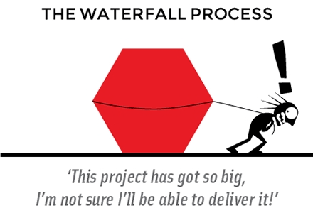

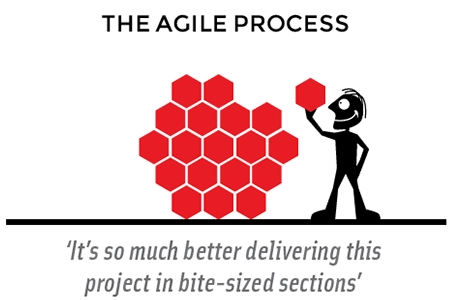

## Reproducibility and Robustness - Determinism and Stability

> *Determinism:* Does the same inputs imply the same outputs?

> *Stability:* Does $x + \delta$ imply $y + \epsilon$?

> **Neither concept is stronger than the other.**

`01:30`

**Task:** Can you think of examples where:

1. Determinism $\;\not\!\!\!\implies$ Stability
2. Stability $\;\not\!\!\!\implies$ Determinism
- High leverage points, Simulated annealing and other Monte Carlo Methods

## Reproducibility and Robustness - In Production

### Computational Worries

- *Input stability:* Failing gracefully and defending against malicious inputs.
- *Computing environment:* Differences in hardware, architecture, OS, language, packages.
- *Scaling:* distributed computing requires careful handling (parallel or federated).

### Statistical Worries

Largest concerns are usually related to changes in distribution. These come in many forms:

- *Sample to population:* Shadow deployment and AB testing
- *Data drift:* Change in marginal distributions $\pi(x)$ or $\pi(y)$
- *Concept drift:* Change in conditional distribution $\pi(y|x)$ or copula.

# Group Discussion

## Task: Contextual Application

In breakout rooms, discuss the main concerns you would have with the following data science projects with regard to reproducibility and stability.

*Reproducibility, Robustness, Workflows, Determinism, Stability, Productionizing*

1. Hierarchical prediction of student grades in districts, schools and classes.
2. Real-time detection of fraudulent bank transactions.
3. Customer segmentation for playlist recommendations.
4. Forecasting call volumes to determine ambulance staffing levels.

# Group Feedback

## Group 1

`04:00`

*Topic:* Hierarchical prediction of student grades

- Reproducibility
- Robustness
- Workflows
- Determinism
- Stability
- Productionizing

> Pick 1 or 2 topics that you thought were mores interesting or relevant to your application.

> Summarise your discussions on these topics for the rest of the group.

## Group 2

`04:00`

*Topic:* Fraudulent bank transactions

- Reproducibility
- Robustness
- Workflows
- Determinism
- Stability
- Productionizing

> Pick 1 or 2 topics that you thought were mores interesting or relevant to your application.

> Summarise your discussions on these topics for the rest of the group.

## Group 3

`04:00`

*Topic:* Playlist customer segmentation

- Reproducibility
- Robustness
- Workflows
- Determinism
- Stability
- Productionizing

> Pick 1 or 2 topics that you thought were mores interesting or relevant to your application.

> Summarise your discussions on these topics for the rest of the group.

## Group 4

`04:00`

*Topic:* Forecasting ambulance call volumes

- Reproducibility
- Robustness
- Workflows
- Determinism
- Stability
- Productionizing

> Pick 1 or 2 topics that you thought were mores interesting or relevant to your application.

> Summarise your discussions on these topics for the rest of the group.

# Thank you. Questions?

[figure not shown]

MLDS Ethics, Part 3 - Zak Varty